# Homework 6

*Enter your name and EID here*

**This homework is due on March 29, 2021 at 11:00pm. Please submit as a pdf file on Canvas.**

For all problems in this homework, we will work with the `BA_degrees` dataset. It contains the proportions of Bachelor’s degrees awarded in the US between 1970 and 2015.

```r
BA_degrees <- read_csv("https://wilkelab.org/SDS375/datasets/BA_degrees.csv")
BA_degrees
```

```
## # A tibble: 594 x 4
##    field                                              year  count     perc
##    <chr>                                             <dbl>  <dbl>    <dbl>
##  1 Agriculture and natural resources                  1971  12672 0.0151
##  2 Architecture and related services                  1971   5570 0.00663
##  3 Area, ethnic, cultural, gender, and group studies  1971   2579 0.00307
##  4 Biological and biomedical sciences                 1971  35705 0.0425
##  5 Business                                           1971 115396 0.137
##  6 Communication, journalism, and related programs    1971  10324 0.0123
##  7 Communications technologies                        1971    478 0.000569
##  8 Computer and information sciences                  1971   2388 0.00284
##  9 Education                                          1971 176307 0.210
## 10 Engineering                                        1971  45034 0.0536
## # … with 584 more rows
```

**Problem 1: (3 pts)**

```r
BA_degrees_2015 <- BA_degrees %>%
  filter(year == 2015) %>%
  arrange(desc(perc))

print(BA_degrees_2015, n = nrow(BA_degrees_2015))
```

```
## # A tibble: 33 x 4
##    field                                                    year  count     perc
##    <chr>                                                   <dbl>  <dbl>    <dbl>
##  1 Business                                                 2015 363799  1.92e-1
##  2 Health professions and related programs                  2015 216228  1.14e-1
##  3 Social sciences and history                              2015 166944  8.81e-2
##  4 Psychology                                               2015 117557  6.20e-2
##  5 Biological and biomedical sciences                       2015 109896  5.80e-2
##  6 Engineering                                              2015  97858  5.16e-2
##  7 Visual and performing arts                               2015  95832  5.06e-2
##  8 Education                                                2015  91623  4.84e-2
##  9 Communication, journalism, and related programs          2015  90650  4.78e-2
## 10 Homeland security, law enforcement, and firefighting     2015  62723  3.31e-2
## 11 Computer and information sciences                        2015  59581  3.14e-2
## 12 Parks, recreation, leisure, and fitness studies          2015  49006  2.59e-2
```

[output cut: 21 more lines]

If you wanted to visualize the relative proportion of these different degree areas, which plot would be most appropriate? A pie chart, a stacked bar chart, or side-by-side bars? Please explain your reasoning. You do not have to make the chart.

**Answer:** Side-by-side bars are the most appropriate choice for this visualization. There are too many different categories for either a pie chart or a stacked bar chart. Neither work well in this circumstance, see the slides from the visualizing proportions class: https://wilkelab.org/SDS375/slides/visualizing-proportions.html#13

**Problem 2: (5 pts)** Now make a pie chart of the `BA_degrees_2015` dataset, but show only the four most common areas, plus all others lumped together into “Other”. (The code to prepare this lumped dataset has been provided for your convenience.) Make sure the pie slices are arranged in a reasonable order. Choose a reasonable color scale and a clean theme that avoids distracting visual elements.

Grading rubric: 3 pts for making the right plot, 2 pts for visual design

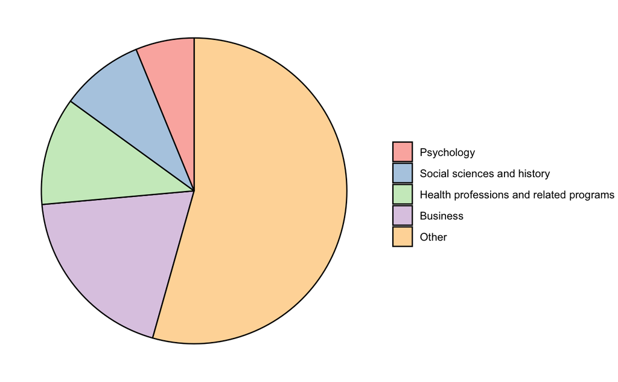

```r
# data preparation
top_four <- BA_degrees_2015$field[1:4]  # works because we sorted by perc in Problem 1
BA_degrees_lumped <- BA_degrees_2015 %>%
  mutate(field = ifelse(field %in% top_four, field, "Other")) %>%
  group_by(field) %>%
  summarize(perc = sum(perc))

# solution 1, polar coords
ggplot(BA_degrees_lumped) +
  aes(perc, "", fill = fct_reorder(field, perc)) +
  geom_col(color = "black") +
  scale_fill_brewer(type = "qual", palette = 4, name = NULL) +
  coord_polar() +
  theme_void()
```

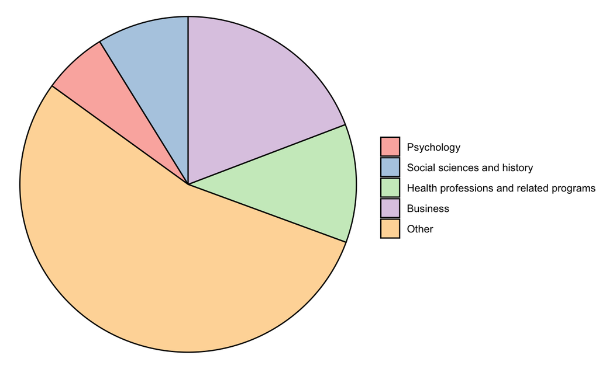

```r
# solution 2, cartesian coords
library(ggforce)

ggplot(BA_degrees_lumped) +
  aes(
    x0 = 0, y0 = 0, # position of pie center
    r0 = 0, r = 1,  # inner and outer radius
    amount = perc, # size of pie slices
    fill = fct_reorder(field, perc)
  ) +
  geom_arc_bar(stat = "pie") +
  scale_fill_brewer(type = "qual", palette = 4, name = NULL) +
  coord_fixed() +
  theme_void()
```

**Problem 3: (2 pts)** Now go back to the entire dataset `BA_degrees` but focus only on the degree field `"Parks, recreation, leisure, and fitness studies"`. Plot a time series of the proportion of degrees (colum `perc`) in this field over time. Also plot a straight line fit to the data. What do you observe?

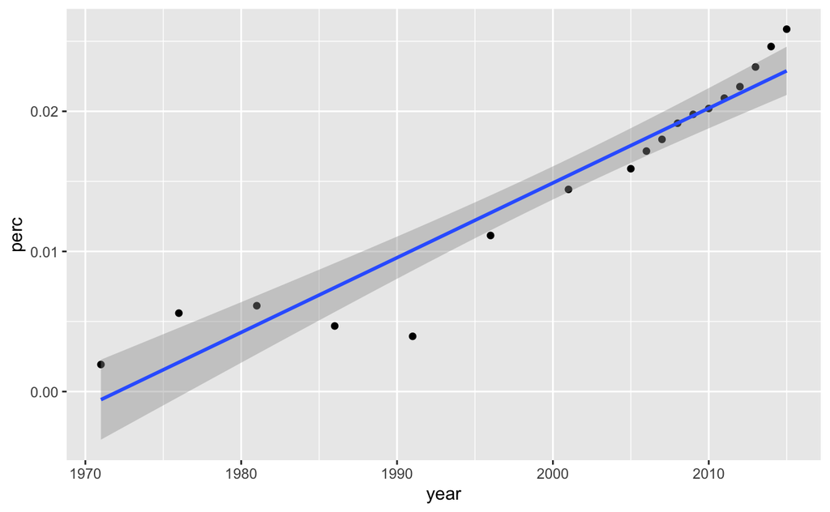

```r
BA_degrees %>%
  filter(field == "Parks, recreation, leisure, and fitness studies") %>%
  ggplot(aes(year, perc)) +
  geom_point() +
  geom_smooth(method = "lm")
```